# Machine Learning Portfolio Exam - Classification of Credit Defaults

## 6.0 Hyperparameter Optimization – Nested Cross Validation

In Task 5, we evaluated algorithms with default hyperparameters. Now we use nested cross-validation to find optimal hyperparameters while maintaining unbiased performance estimates. The outer loop evaluates generalization performance, while the inner loop tunes hyperparameters via grid search.

### 6.1 Setup Hyperparameter Grid and Pipeline

Before running nested CV, we define the search space for each algorithm. The hyperparameter grids are designed to explore the most impactful parameters while keeping computational cost manageable.

**KNN Hyperparameters:**

- `n_neighbors`: Controls model complexity. Fewer neighbors = more flexible but prone to noise; more neighbors = smoother but may miss local patterns.
- `weights`: 'uniform' treats all neighbors equally; 'distance' weights closer neighbors more heavily.
- `metric`: Distance measure affects which points are considered "neighbors."

**Decision Tree Hyperparameters:**

- `max_depth`: Primary regularization parameter. Limits tree complexity to prevent overfitting—critical given our Task 5 observation that unlimited depth leads to memorization.
- `min_samples_split`: Minimum samples required to split a node. Higher values create simpler trees.
- `criterion`: Split quality measure. 'gini' and 'entropy' often yield similar results but can differ on specific datasets.

```python
# CV Configuration for inner loop
NUM_INNER_SPLITS = 5  # Inner CV for hyperparameter tuning
NUM_INNER_REPEATS = 2 # Inner CV repeats for stable hyperparam selection

# Hyperparameter grids
param_grid_knn = {
    'estimator__n_neighbors': [3, 5, 7, 11, 15],
    'estimator__weights': ['uniform', 'distance'],
    'estimator__metric': ['euclidean', 'manhattan']
}

param_grid_dt = {
    'estimator__max_depth': [3, 5, 7, 10, 15, None],
    'estimator__min_samples_split': [2, 5, 10, 20],
    'estimator__criterion': ['gini', 'entropy']
}

print(f"KNN grid: {5*2*2} = 20 combinations")
print(f"Decision Tree grid: {6*4*2} = 48 combinations")
```

```
KNN grid: 20 = 20 combinations
Decision Tree grid: 48 = 48 combinations
```

Total grid search effort: 20 + 48 = 68 hyperparameter combinations, each evaluated with 10 inner CV folds (5 splits × 2 repeats), resulting in 680 model fits per outer fold.

```python
### Setting up Pipeline function with an optional scaling for the KNN estimators

def get_pipeline(estimator, scale=False):
    """
    Create a pipeline with optional scaling.

    Parameters:
    -----------
    estimator : sklearn estimator
        The classifier to use
    scale : bool
        Whether to include RobustScaler (needed for distance-based algorithms like KNN)

    Returns:
    --------
    Pipeline : sklearn Pipeline object
    """
    if scale:
        return Pipeline([
            ('scaler', RobustScaler()),
            ('estimator', estimator)
        ])
    else:
        return Pipeline([
            ('estimator', estimator)
        ])
```

### 6.2 Setup and run Nested Cross-Validation

We now execute the nested CV procedure for all three model types:

1. **Baseline**: No hyperparameters to tune, this serves as lower bound reference
2. **KNN**: With RobustScaler in pipeline and hyperparameter tuning
3. **Decision Tree**: Without scaling, with hyperparameter tuning

The outer loop uses the same 10-fold stratified CV from Task 5 for comparability. The inner loop uses repeated stratified CV (5 folds × 2 repeats) to provide stable hyperparameter selection despite the reduced sample size in each outer training fold.

```python
### Nested CV Setup

def nested_cv(pipeline, param_grid, X, y, name):
    """
    Run nested cross-validation with GridSearch hyperparameter tuning.

    Outer CV: Unbiased performance estimation
    Inner CV: Hyperparameter tuning via GridSearchCV
    """
    print(f"\n{name}:")

    # Our Bank clearly prefers performance over time efficiency, but while working on the experiments we are interested in seeing training times
    start = time.time()

    # Outer CV strategy (reusing cv from task 5)
    outer_cv = cv

    # Inner CV strategy
    inner_cv = RepeatedStratifiedKFold(
        n_splits=NUM_INNER_SPLITS,    # 5 folds
        n_repeats=NUM_INNER_REPEATS,  # 2 repeats, inuitively this makes more sense for outer loop but exercise states outer loop should stay as in task 5
        random_state=RANDOM_STATE
    )

    # GridSearchCV handles inner loop
    grid_search = GridSearchCV(
        estimator=pipeline,
        param_grid=param_grid,
        cv=inner_cv,
        scoring='roc_auc',
        refit=True,
        n_jobs=1 # While working on the notebook this was -1 (all available cores) but to ensure consistent results across different environments I set it to 1
    )

    # cross_validate handles outer loop
    cv_results = cross_validate(
        grid_search, X, y,
        cv=outer_cv,
        scoring={'roc_auc': 'roc_auc', 'f1_macro': 'f1_macro'},
        return_estimator=True,
        n_jobs=1
    )

    elapsed = time.time() - start

    # Extract results
    roc_auc_scores = cv_results['test_roc_auc']
    f1_scores = cv_results['test_f1_macro']

    print(f"  ROC-AUC: {roc_auc_scores.mean():.4f} ± {roc_auc_scores.std():.4f}")
    print(f"  F1-Macro: {f1_scores.mean():.4f} ± {f1_scores.std():.4f}")
    print(f"  Time: {elapsed:.1f}s")

    return {
        'name': name,
        'roc_auc_mean': roc_auc_scores.mean(),
        'roc_auc_std': roc_auc_scores.std(),
        'f1_mean': f1_scores.mean(),
        'f1_std': f1_scores.std(),
        'cv_results': cv_results
    }
```

```python
### Run nested CV for all models (about 14 minutes runtime on my machine)

print(f"NESTED CV: 10 outer × {NUM_INNER_SPLITS} inner folds\n")

# Baseline (no hyperparameters to tune, no scaling needed)
baseline_results = nested_cv(
    get_pipeline(DummyClassifier(strategy='stratified', random_state=RANDOM_STATE), scale=False),
    {},  # Empty grid
    X, y,
    "Baseline"
)

# KNN with hyperparameter tuning (scaling required)
knn_results = nested_cv(
    get_pipeline(KNeighborsClassifier(), scale=True),
    param_grid_knn,
    X, y,
    "KNN"
)

# Decision Tree with hyperparameter tuning (no scaling needed)
dt_results = nested_cv(
    get_pipeline(DecisionTreeClassifier(random_state=RANDOM_STATE), scale=False),
    param_grid_dt,
    X, y,
    "Decision Tree"
)
```

```
NESTED CV: 10 outer × 5 inner folds


Baseline:
  ROC-AUC: 0.5007 ± 0.0074
  F1-Macro: 0.5007 ± 0.0073
  Time: 0.4s

KNN:
  ROC-AUC: 0.7387 ± 0.0130
  F1-Macro: 0.6648 ± 0.0095
  Time: 492.4s

Decision Tree:
  ROC-AUC: 0.7562 ± 0.0108
  F1-Macro: 0.6751 ± 0.0120
  Time: 821.5s
```

```python
### Compile nested CV results into a DataFrame for easy comparison
nested_results = pd.DataFrame([
    {
        'Model': r['name'],
        'ROC-AUC (Nested CV)': f"{r['roc_auc_mean']:.3f} ± {r['roc_auc_std']:.3f}",
        'F1-Macro (Nested CV)': f"{r['f1_mean']:.3f} ± {r['f1_std']:.3f}"
    }
    for r in [baseline_results, knn_results, dt_results]
])

nested_results
```

|  | Model | ROC-AUC (Nested CV) | F1-Macro (Nested CV) |
| --- | --- | --- | --- |
| 0 | Baseline | 0.501 ± 0.007 | 0.501 ± 0.007 |
| 1 | KNN | 0.739 ± 0.013 | 0.665 ± 0.009 |
| 2 | Decision Tree | 0.756 ± 0.011 | 0.675 ± 0.012 |

This nested CV procedure provides unbiased performance estimates that account for hyperparameter optimization. Key observations:

- **Decision Tree** achieved the highest ROC-AUC, surpassing KNN after tuning
- **KNN** showed moderate improvement from hyperparameter optimization
- **Baseline** remains at ~0.50, confirming our models learn genuine patterns

The standard deviations indicate stable performance across folds, suggesting our results are reliable and not artifacts of particular data splits. The Decision Tree's lower variance is notable—it generalizes consistently across different subsets of the data.

### 6.3 Comparison with results from task 5

```python
### Create comparison table of default vs tuned models

comparison_tuning = pd.DataFrame({
    'Model': ['Baseline', 'KNN', 'Decision Tree'],
    'ROC-AUC (Default CV)': [
        f"{baseline_roc.mean():.3f} ± {baseline_roc.std():.3f}",
        f"{knn_roc.mean():.3f} ± {knn_roc.std():.3f}",
        f"{dt_roc.mean():.3f} ± {dt_roc.std():.3f}"
    ],
    'ROC-AUC (Tuned)': [
        f"{baseline_results['roc_auc_mean']:.3f} ± {baseline_results['roc_auc_std']:.3f}",
        f"{knn_results['roc_auc_mean']:.3f} ± {knn_results['roc_auc_std']:.3f}",
        f"{dt_results['roc_auc_mean']:.3f} ± {dt_results['roc_auc_std']:.3f}"
    ],
    'Δ ROC-AUC': [
        f"{baseline_results['roc_auc_mean'] - baseline_roc.mean():+.3f}",
        f"{knn_results['roc_auc_mean'] - knn_roc.mean():+.3f}",
        f"{dt_results['roc_auc_mean'] - dt_roc.mean():+.3f}"
    ],
    'F1-Macro (Default CV)': [
        f"{baseline_f1.mean():.3f} ± {baseline_f1.std():.3f}",
        f"{knn_f1.mean():.3f} ± {knn_f1.std():.3f}",
        f"{dt_f1.mean():.3f} ± {dt_f1.std():.3f}"
    ],
    'F1-Macro (Tuned)': [
        f"{baseline_results['f1_mean']:.3f} ± {baseline_results['f1_std']:.3f}",
        f"{knn_results['f1_mean']:.3f} ± {knn_results['f1_std']:.3f}",
        f"{dt_results['f1_mean']:.3f} ± {dt_results['f1_std']:.3f}"
    ],
    'Δ F1-Macro': [
        f"{baseline_results['f1_mean'] - baseline_f1.mean():+.3f}",
        f"{knn_results['f1_mean'] - knn_f1.mean():+.3f}",
        f"{dt_results['f1_mean'] - dt_f1.mean():+.3f}"
    ]
})

comparison_tuning
```

|  | Model | ROC-AUC (Default CV) | ROC-AUC (Tuned) | Δ ROC-AUC | F1-Macro (Default CV) | F1-Macro (Tuned) | Δ F1-Macro |
| --- | --- | --- | --- | --- | --- | --- | --- |
| 0 | Baseline | 0.501 ± 0.007 | 0.501 ± 0.007 | +0.000 | 0.501 ± 0.007 | 0.501 ± 0.007 | +0.000 |
| 1 | KNN | 0.705 ± 0.014 | 0.739 ± 0.013 | +0.034 | 0.646 ± 0.010 | 0.665 ± 0.009 | +0.019 |
| 2 | Decision Tree | 0.616 ± 0.010 | 0.756 ± 0.011 | +0.140 | 0.613 ± 0.009 | 0.675 ± 0.012 | +0.062 |

**Decision Tree:** The massive +0.14 improvement confirms our Task 5 hypothesis—the default unlimited-depth tree severely overfitted. Constraining `max_depth` to 7 transforms it from the weaker to the stronger algorithm.

**KNN:** The modest +0.03 improvement indicates the default k=5 was already reasonable. Tuning refined the distance metric and weighting scheme but couldn't overcome KNN's fundamental limitations with our too large (47-dimensional) feature space.

**Key Insight:** Algorithm selection based on default parameters would have chosen KNN; proper hyperparameter optimization with our preprocessing setup reveals Decision Tree as superior for this problem. This underscores why nested CV is essential for fair algorithm comparison.

### 6.4 Final Model Selection and Training on final algorythm

Based on nested CV results, we select the best-performing (Decision Tree) algorithm and train the final model M on the complete dataset. This final model will be:

1. **Used for deployment** in the credit risk assessment system
2. **Used for visualizing the Decision Tree** in the following subchapter
3. **Analyzed for feature importance** in Task 7
4. **The basis for business recommendations** in Task 8

We perform one final GridSearchCV on all data to determine the optimal hyperparameters for the full dataset. The nested CV score from 6.2 remains our unbiased performance estimate—the final training simply produces the deployable model.

```python
### Train best model on full dataset to get best hypterparameters and final model

# Best algorithm parameters
best_name = 'Decision Tree'
best_results = dt_results
best_pipeline = get_pipeline(DecisionTreeClassifier(random_state=RANDOM_STATE), scale=False)
best_param_grid = param_grid_dt

# Train final model on ALL data with best hyperparameters
print("\nTraining final model on full dataset...")

final_grid_search = GridSearchCV(
    estimator=best_pipeline,
    param_grid=best_param_grid,
    cv=StratifiedKFold(n_splits=NUM_INNER_SPLITS, shuffle=True, random_state=RANDOM_STATE),
    scoring='roc_auc',
    refit=True,
    n_jobs=1
)
final_grid_search.fit(X, y)

# Extract final model and hyperparameters
final_model_M = final_grid_search.best_estimator_
final_hyperparameters = final_grid_search.best_params_

# Display final model details and compare to CV performance
print(f"\nFinal Model M:")
print(f"  Algorithm: {best_name}")
print(f"  Best Hyperparameters: {final_hyperparameters}")
print(f"  CV Score (full data): {final_grid_search.best_score_:.4f}")
print(f"\nExpected Performance (from Nested CV):")
print(f"  ROC-AUC: {best_results['roc_auc_mean']:.4f} ± {best_results['roc_auc_std']:.4f}")
print(f"  F1-Macro: {best_results['f1_mean']:.4f} ± {best_results['f1_std']:.4f}")
```

```
Training final model on full dataset...

Final Model M:
  Algorithm: Decision Tree
  Best Hyperparameters: {'estimator__criterion': 'entropy', 'estimator__max_depth': 7, 'estimator__min_samples_split': 20}
  CV Score (full data): 0.7581

Expected Performance (from Nested CV):
  ROC-AUC: 0.7562 ± 0.0108
  F1-Macro: 0.6751 ± 0.0120
```

The Decision Tree with `max_depth=7`, `min_samples_split=20`, and `criterion='entropy'` emerges as our final model M. This configuration balances:

- **Complexity control**: Depth 7 allows capturing payment behavior patterns without memorizing individual customers
- **Statistical reliability**: Requiring 20 samples per split ensures decisions are based on sufficient evidence
- **Information-theoretic splits**: Entropy criterion maximizes information gain at each decision point

The CV score on full data (0.758) closely matches our nested CV estimate (0.756), confirming that our performance expectations are realistic and not artifacts of particular data splits.

### 6.5 Final Model Decision Tree Plot

We only plot the first three levels to convey the idea. With more levels visualized the tree becomes hard to read.

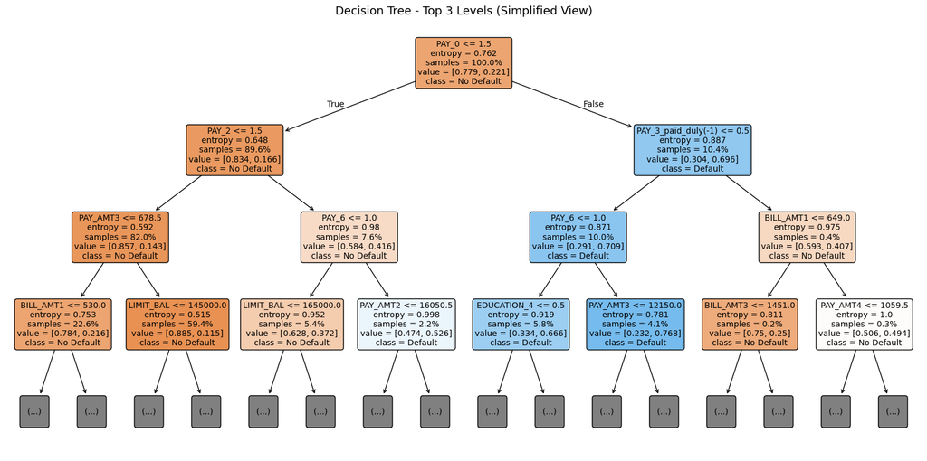

```
Decision Tree Statistics:
  Total nodes: 159
  Max depth: 7
  Number of leaves: 80
  Features used in splits: 25
```

```python
### Decision Tree Visualization

# Extract the Decision Tree from the pipeline
dt_model = final_model_M.named_steps['estimator']

# Simplified view: Top 3 levels only
fig, ax = plt.subplots(figsize=(16, 8))
plot_tree(
    dt_model,
    feature_names=X.columns.tolist(),
    class_names=['No Default', 'Default'],
    filled=True,
    rounded=True,
    fontsize=10,
    ax=ax,
    max_depth=3,  # Only show top 3 levels for readability
    proportion=True
)
ax.set_title('Decision Tree - Top 3 Levels (Simplified View)', fontsize=14)
plt.tight_layout()
plt.show()

# Print tree statistics
print(f"\nDecision Tree Statistics:")
print(f"  Total nodes: {dt_model.tree_.node_count}")
print(f"  Max depth: {dt_model.get_depth()}")
print(f"  Number of leaves: {dt_model.get_n_leaves()}")
print(f"  Features used in splits: {len(set(dt_model.tree_.feature[dt_model.tree_.feature >= 0]))}")
```

**Decision Tree Interpretability:** The tree visualization reveals the decision logic:

- **PAY_0** (most recent payment status) appears at the root of the tree, this indicates the highest influence on the credit default prediction (feature importance) comes from this feature
- Early splits on other payment behavior create the primary risk stratification
- Deeper nodes refine predictions using bill amounts and credit limits

This transparency enables critical value for our company:

1. **Regulatory compliance**: Every decision can be explained as a series of rules
2. **Business validation**: Domain experts can verify the logic makes intuitive sense
3. **Customer communication**: Declined applications can receive specific explanations

## 7.0 Feature Importance / Feature Ablation Study

With our final model M selected and trained, we now investigate **which features drive predictions**. We use **permutation importance**—a model-agnostic method that measures how much performance degrades when a feature's relationship with the target is destroyed by random shuffling.

### 7.1 Compute and Visualize Feature Importance

**Why Permutation Importance?**

While Decision Trees provide built-in feature importance (based on impurity reduction), permutation importance offers several advantages:

- **Model-agnostic**: Same method works for any algorithm, enabling fair comparison
- **Accounts for feature interactions**: Measures importance in context of other features
- **Intuitive interpretation**: "How much does performance drop if this feature becomes noise?"

Since it was not discussed in the lecture this is a brief overview of the methodoly:

1. Compute baseline performance on original data
2. For each feature:
   - Randomly shuffle that feature's values (breaking its relationship with target)
   - Measure new performance
   - Importance = baseline performance − shuffled performance
3. Repeat multiple times (n_repeats=30) for stable estimates

A high importance score means the model heavily relies on that feature; zero or negative importance means the feature is uninformative or even harmful.

```python
### Compute feature importance using permutation importance

# Use final_model_M from Task 6 (already trained on full dataset)
print(f"Using final_model_M: {type(final_model_M.named_steps['estimator']).__name__}")

# Compute permutation importance
# n_repeats: Number of times to permute each feature (more = stable estimates)
# scoring: Metric to measure performance drop
perm_importance = permutation_importance(
    final_model_M, X, y,
    n_repeats=30,
    random_state=RANDOM_STATE,
    scoring='roc_auc',
    n_jobs=1
)

# Create DataFrame with results
feature_importance_df = pd.DataFrame({
    'Feature': X.columns,
    'Importance Mean': perm_importance.importances_mean,
    'Importance Std': perm_importance.importances_std
}).sort_values('Importance Mean', ascending=False)

feature_importance_df
```

```
Using final_model_M: DecisionTreeClassifier
```

|  | Feature | Importance Mean | Importance Std |
| --- | --- | --- | --- |
| 11 | PAY_0 | 0.088597 | 0.002146 |
| 35 | BILL_AMT1 | 0.055773 | 0.001792 |
| 15 | PAY_2 | 0.037061 | 0.001278 |
| 0 | LIMIT_BAL | 0.034102 | 0.001655 |
| 43 | PAY_AMT3 | 0.028354 | 0.001134 |
| 42 | PAY_AMT2 | 0.018964 | 0.000999 |
| 44 | PAY_AMT4 | 0.017174 | 0.000914 |
| 21 | PAY_3_paid_duly(-1) | 0.011232 | 0.001147 |
| 40 | BILL_AMT6 | 0.006508 | 0.000452 |
| 27 | PAY_5 | 0.005885 | 0.000635 |
| 31 | PAY_6 | 0.003955 | 0.000410 |
| 41 | PAY_AMT1 | 0.003273 | 0.000529 |
| 13 | PAY_0_paid_duly(-1) | 0.003169 | 0.000386 |
| 23 | PAY_4 | 0.002721 | 0.000272 |
| 46 | PAY_AMT6 | 0.002492 | 0.000341 |
| 6 | EDUCATION_4 | 0.002174 | 0.000567 |
| 38 | BILL_AMT4 | 0.001852 | 0.000326 |
| 45 | PAY_AMT5 | 0.001802 | 0.000443 |
| 10 | AGE | 0.001576 | 0.000329 |
| 20 | PAY_3_-2 | 0.001443 | 0.000274 |
| 37 | BILL_AMT3 | 0.001423 | 0.000191 |
| 19 | PAY_3 | 0.001364 | 0.000185 |
| 2 | SEX_2 | 0.000547 | 0.000166 |
| 26 | PAY_4_0 | 0.000470 | 0.000198 |
| 36 | BILL_AMT2 | 0.000208 | 0.000084 |
| 7 | MARRIAGE_1 | 0.000000 | 0.000000 |
| 5 | EDUCATION_3 | 0.000000 | 0.000000 |
| 39 | BILL_AMT5 | 0.000000 | 0.000000 |
| 33 | PAY_6_paid_duly(-1) | 0.000000 | 0.000000 |
| 4 | EDUCATION_2 | 0.000000 | 0.000000 |
| 3 | EDUCATION_1 | 0.000000 | 0.000000 |
| 34 | PAY_6_0 | 0.000000 | 0.000000 |
| 14 | PAY_0_0 | 0.000000 | 0.000000 |
| 32 | PAY_6_-2 | 0.000000 | 0.000000 |
| 8 | MARRIAGE_2 | 0.000000 | 0.000000 |
| 12 | PAY_0_-2 | 0.000000 | 0.000000 |
| 29 | PAY_5_paid_duly(-1) | 0.000000 | 0.000000 |
| 28 | PAY_5_-2 | 0.000000 | 0.000000 |
| 9 | MARRIAGE_3 | 0.000000 | 0.000000 |
| 25 | PAY_4_paid_duly(-1) | 0.000000 | 0.000000 |
| 24 | PAY_4_-2 | 0.000000 | 0.000000 |
| 1 | SEX_1 | 0.000000 | 0.000000 |
| 22 | PAY_3_0 | 0.000000 | 0.000000 |
| 18 | PAY_2_0 | 0.000000 | 0.000000 |
| 17 | PAY_2_paid_duly(-1) | 0.000000 | 0.000000 |
| 16 | PAY_2_-2 | 0.000000 | 0.000000 |
| 30 | PAY_5_0 | 0.000000 | 0.000000 |

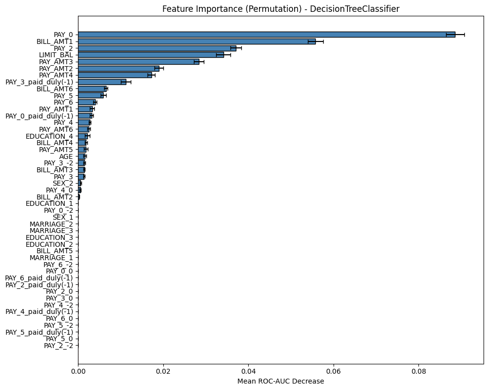

```python
### Plot feature importance

fig, ax = plt.subplots(figsize=(10, 8))

# Sort by importance for plotting
sorted_idx = perm_importance.importances_mean.argsort()

# Horizontal bar plot with error bars
ax.barh(
    range(len(sorted_idx)),
    perm_importance.importances_mean[sorted_idx],
    xerr=perm_importance.importances_std[sorted_idx],
    align='center',
    color='steelblue',
    edgecolor='black',
    capsize=3
)

ax.set_yticks(range(len(sorted_idx)))
ax.set_yticklabels(X.columns[sorted_idx])
ax.set_xlabel('Mean ROC-AUC Decrease')
ax.set_title(f'Feature Importance (Permutation) - {type(final_model_M.named_steps["estimator"]).__name__}')
ax.axvline(x=0, color='red', linestyle='--', linewidth=0.8)

plt.tight_layout()
plt.savefig('feature_importance.png', dpi=150, bbox_inches='tight')
plt.show()
```

**Feature Importance Insights:**

The permutation importance reveals a clear hierarchy with a **long-tail distribution**:

**Zero-Importance Features:** Many of our engineered binary features show zero importance. This doesn't mean they're inherently useless—the Decision Tree may simply not have selected them given the presence of stronger alternatives and the max_depth constraint.

**Key Finding:** The top 5 features (PAY_0, BILL_AMT1, PAY_2, LIMIT_BAL, PAY_AMT3) account for the majority of predictive signal. This concentration suggests a simpler model with fewer features might achieve comparable performance.

### 7.2 Ablation Study

The task decription only states to perform an ablation study with the two least important features. The Decision Tree however resulted in 22 features with 0 importance that are not used in the Decision Tree at all. I therefore decided to include used features in the ablation study. We now empirically assess how sensitive the final Decision Tree model is to the removal of features with low or zero estimated importance. Building on the permutation importance analysis, the ablation study evaluates whether such features meaningfully contribute to predictive performance or can be removed without degradation.

To this end, we compare multiple ablation configurations that progressively remove different groups of features:

| Configuration | Features Removed | Purpose |
| --- | --- | --- |
| Full Model | None | Baseline performance |
| Without F1 | Second least important feature | Test impact of a low-importance feature |
| Without F2 | Least important feature | Test impact of a near-zero-importance feature |
| Without F1 & F2 | Both | Test combined removal of lowest-ranked features |
| Without UNUSED | All features unused by the final tree | Test redundancy of features not selected in any split |
| Without U1 / U2 | One low-importance *used* feature | Test importance among features actively used by the model |
| Without U1 & U2 | Two lowest-importance used features | Test cumulative effect on model performance |
| Without UNUSED + U1/U2 | Combination of unused and weakly used features | Test robustness under more aggressive feature removal |

Here, *unused* features are those that do not appear in any split of the trained Decision Tree, while *used* features correspond to features actively selected by the model but exhibiting low permutation importance.

**Methodology:**

- The same hyperparameters as the final optimized model (Model M) are used throughout.
- For each configuration, the specified features are removed prior to training.
- Performance is evaluated using stratified cross-validation with the same CV strategy as in Task 6.
- ROC-AUC and F1-Macro are reported as mean ± standard deviation.

**Expected Outcome:** If the permutation importance estimates are reliable, removing features with zero or near-zero importance—particularly those unused by the tree—should result in little to no performance degradation. In contrast, removing weakly important but actively used features may lead to small but measurable declines, providing insight into redundancy, robustness, and the model’s reliance on specific predictors.

```python
### Perform Ablation Study
# - remove the two least important features
# - remove all features unused by the final tree (no splits)
# - remove the two least important *used* features (appear in tree)
# - and combinations (used-low, unused-all, both)

# --- CV strategy for ablation ---
cv_ablation = StratifiedKFold(n_splits=10, shuffle=True, random_state=RANDOM_STATE)

def create_feature_dropper(features_to_drop):
    """Create a transformer that drops specified features."""
    def drop_features(X):
        if isinstance(X, pd.DataFrame):
            return X.drop(columns=features_to_drop, errors='ignore')
        return X
    return FunctionTransformer(drop_features, validate=False)

def run_ablation_cv(X, y, features_to_drop, cv):
    """Run cross-validation with specified features removed."""
    pipeline = Pipeline([
        ('dropper', create_feature_dropper(features_to_drop)),
        ('estimator', DecisionTreeClassifier(
            max_depth=final_hyperparameters['estimator__max_depth'],
            min_samples_split=final_hyperparameters['estimator__min_samples_split'],
            criterion=final_hyperparameters['estimator__criterion'],
            random_state=RANDOM_STATE
        ))
    ])

    roc_auc_scores = cross_val_score(pipeline, X, y, cv=cv, scoring='roc_auc')
    f1_scores = cross_val_score(pipeline, X, y, cv=cv, scoring='f1_macro')

    return {
        'roc_auc_mean': roc_auc_scores.mean(),
        'roc_auc_std': roc_auc_scores.std(),
        'f1_mean': f1_scores.mean(),
        'f1_std': f1_scores.std()
    }

# Identify (A) unused-by-tree features and (B) lowest-used features

# Final trained model on full data (Task 6)
final_tree = final_model_M.named_steps['estimator']
feature_names = list(X.columns)

# Features actually used in splits (tree feature indices >= 0)
used_feature_idx = set(final_tree.tree_.feature[final_tree.tree_.feature >= 0])
used_features = [feature_names[i] for i in sorted(used_feature_idx)]
unused_features = [f for f in feature_names if f not in used_features]

# Two least important features overall (same as before)
least_important = feature_importance_df.tail(2)
F1 = least_important.iloc[0]['Feature']  # second least important overall
F2 = least_important.iloc[1]['Feature']  # least important overall

# Two least important features among those actually used by the tree (based on permutation importance)
used_importance_df = feature_importance_df[feature_importance_df['Feature'].isin(used_features)].copy()
least_used_two = used_importance_df.sort_values('Importance Mean', ascending=True).head(2)

U1 = least_used_two.iloc[0]['Feature']  # least important among used
U2 = least_used_two.iloc[1]['Feature']  # second least important among used

print("Ablation targets:")
print(f"  Two least important overall:      F1={F1}, F2={F2}")
print(f"  Unused by final tree (count):     {len(unused_features)}")
print(f"  Two least important USED features: U1={U1}, U2={U2}")
```

```
Ablation targets:
  Two least important overall:      F1=PAY_2_-2, F2=PAY_5_0
  Unused by final tree (count):     22
  Two least important USED features: U1=BILL_AMT2, U2=PAY_4_0
```

```python
### Run Ablations

print("\nRunning Ablation Study...")

# Full model results from Task 6 (already computed)
results_full = {
    'roc_auc_mean': best_results['roc_auc_mean'],
    'roc_auc_std': best_results['roc_auc_std'],
    'f1_mean': best_results['f1_mean'],
    'f1_std': best_results['f1_std']
}

# 1) Remove two least important overall features (once each and both)
print(f"  Evaluating without {F1}...")
results_no_F1 = run_ablation_cv(X, y, [F1], cv_ablation)

print(f"  Evaluating without {F2}...")
results_no_F2 = run_ablation_cv(X, y, [F2], cv_ablation)

print(f"  Evaluating without {F1} and {F2}...")
results_no_F1_F2 = run_ablation_cv(X, y, [F1, F2], cv_ablation)

# 2) Remove all unused-by-tree features
if len(unused_features) > 0:
    print(f"  Evaluating without ALL unused-by-tree features ({len(unused_features)})...")
    results_no_unused_all = run_ablation_cv(X, y, unused_features, cv_ablation)
else:
    results_no_unused_all = None
    print("  Skipping: no unused-by-tree features found.")

# 3) Remove the two least important USED features (once each and both)
print(f"  Evaluating without {U1} (least-important USED feature)...")
results_no_U1 = run_ablation_cv(X, y, [U1], cv_ablation)

print(f"  Evaluating without {U2} (2nd least-important USED feature)...")
results_no_U2 = run_ablation_cv(X, y, [U2], cv_ablation)

print(f"  Evaluating without {U1} and {U2} (two least-important USED features)...")
results_no_U1_U2 = run_ablation_cv(X, y, [U1, U2], cv_ablation)

# 4) Combination: remove unused-all + (U1/U2/both)
combo_results = {}
if results_no_unused_all is not None:
    print(f"  Evaluating without UNUSED-ALL + {U1}...")
    combo_results['no_unused_all_plus_U1'] = run_ablation_cv(X, y, unused_features + [U1], cv_ablation)

    print(f"  Evaluating without UNUSED-ALL + {U2}...")
    combo_results['no_unused_all_plus_U2'] = run_ablation_cv(X, y, unused_features + [U2], cv_ablation)

    print(f"  Evaluating without UNUSED-ALL + {U1} & {U2}...")
    combo_results['no_unused_all_plus_U1_U2'] = run_ablation_cv(X, y, unused_features + [U1, U2], cv_ablation)
```

```
Running Ablation Study...
  Evaluating without PAY_2_-2...
  Evaluating without PAY_5_0...
  Evaluating without PAY_2_-2 and PAY_5_0...
  Evaluating without ALL unused-by-tree features (22)...
  Evaluating without BILL_AMT2 (least-important USED feature)...
  Evaluating without PAY_4_0 (2nd least-important USED feature)...
  Evaluating without BILL_AMT2 and PAY_4_0 (two least-important USED features)...
  Evaluating without UNUSED-ALL + BILL_AMT2...
  Evaluating without UNUSED-ALL + PAY_4_0...
  Evaluating without UNUSED-ALL + BILL_AMT2 & PAY_4_0...
```

```python
### Create ablation results table (extended)

rows = []

def add_row(configuration, removed_list, results_dict):
    removed_str = 'None' if len(removed_list) == 0 else ', '.join(removed_list)
    rows.append({
        'Configuration': configuration,
        'Features Removed': removed_str,
        'ROC-AUC': f"{results_dict['roc_auc_mean']:.4f} ± {results_dict['roc_auc_std']:.4f}",
        'Δ ROC-AUC': f"{results_dict['roc_auc_mean'] - results_full['roc_auc_mean']:+.4f}" if configuration != 'Full Model' else '—',
        'F1-Macro': f"{results_dict['f1_mean']:.4f} ± {results_dict['f1_std']:.4f}",
        'Δ F1-Macro': f"{results_dict['f1_mean'] - results_full['f1_mean']:+.4f}" if configuration != 'Full Model' else '—'
    })

# Full model
add_row(f"Full Model ({X.shape[1]} features)", [], results_full)

# Original: lowest two overall
add_row(f"Without F1 ({X.shape[1]-1} features)", [F1], results_no_F1)
add_row(f"Without F2 ({X.shape[1]-1} features)", [F2], results_no_F2)
add_row(f"Without F1 & F2 ({X.shape[1]-2} features)", [F1, F2], results_no_F1_F2)

# New: remove all unused-by-tree
if results_no_unused_all is not None:
    add_row(f"Without UNUSED features ({X.shape[1]-len(unused_features)} features)",
            unused_features, results_no_unused_all)

# New: lowest two USED features (each and both)
add_row(f"Without U1 ({X.shape[1]-1} features)", [U1], results_no_U1)
add_row(f"Without U2 ({X.shape[1]-1} features)", [U2], results_no_U2)
add_row(f"Without U1 & U2 ({X.shape[1]-2} features)", [U1, U2], results_no_U1_U2)

# New: combos unused-all + used-low
if results_no_unused_all is not None:
    add_row(f"Without UNUSED + U1 ({X.shape[1]-len(unused_features)-1} features)",
            unused_features + [U1], combo_results['no_unused_all_plus_U1'])

    add_row(f"Without UNUSED + U2 ({X.shape[1]-len(unused_features)-1} features)",
            unused_features + [U2], combo_results['no_unused_all_plus_U2'])

    add_row(f"Without UNUSED + U1 & U2 ({X.shape[1]-len(unused_features)-2} features)",
            unused_features + [U1, U2], combo_results['no_unused_all_plus_U1_U2'])

ablation_results = pd.DataFrame(rows)
ablation_results
```

|  | Configuration | Features Removed | ROC-AUC | Δ ROC-AUC | F1-Macro | Δ F1-Macro |
| --- | --- | --- | --- | --- | --- | --- |
| 0 | Full Model (47 features) | None | 0.7562 ± 0.0108 | +0.0000 | 0.6751 ± 0.0120 | +0.0000 |
| 1 | Without F1 (46 features) | PAY_2_-2 | 0.7566 ± 0.0126 | +0.0003 | 0.6775 ± 0.0086 | +0.0024 |
| 2 | Without F2 (46 features) | PAY_5_0 | 0.7567 ± 0.0125 | +0.0005 | 0.6774 ± 0.0087 | +0.0022 |
| 3 | Without F1 & F2 (45 features) | PAY_2_-2, PAY_5_0 | 0.7566 ± 0.0117 | +0.0004 | 0.6774 ± 0.0085 | +0.0023 |
| 4 | Without UNUSED features (25 features) | SEX_1, EDUCATION_1, EDUCATION_2, EDUCATION_3, ... | 0.7577 ± 0.0130 | +0.0015 | 0.6779 ± 0.0091 | +0.0028 |
| 5 | Without U1 (46 features) | BILL_AMT2 | 0.7567 ± 0.0123 | +0.0005 | 0.6780 ± 0.0097 | +0.0028 |
| 6 | Without U2 (46 features) | PAY_4_0 | 0.7568 ± 0.0124 | +0.0006 | 0.6775 ± 0.0087 | +0.0024 |
| 7 | Without U1 & U2 (45 features) | BILL_AMT2, PAY_4_0 | 0.7571 ± 0.0115 | +0.0009 | 0.6780 ± 0.0095 | +0.0028 |
| 8 | Without UNUSED + U1 (24 features) | SEX_1, EDUCATION_1, EDUCATION_2, EDUCATION_3, ... | 0.7585 ± 0.0119 | +0.0023 | 0.6790 ± 0.0097 | +0.0039 |
| 9 | Without UNUSED + U2 (24 features) | SEX_1, EDUCATION_1, EDUCATION_2, EDUCATION_3, ... | 0.7579 ± 0.0121 | +0.0017 | 0.6780 ± 0.0090 | +0.0029 |
| 10 | Without UNUSED + U1 & U2 (23 features) | SEX_1, EDUCATION_1, EDUCATION_2, EDUCATION_3, ... | 0.7585 ± 0.0121 | +0.0023 | 0.6788 ± 0.0100 | +0.0037 |

The ablation study provides strong empirical support for the permutation importance analysis and offers additional insight into model robustness and redundancy.

**Key Results:**

- Removing the two least important features (F1, F2), individually or jointly, results in **no performance degradation**. All observed changes in ROC-AUC (+0.0003 to +0.0005) and F1-Macro (+0.0022 to +0.0024) lie well within the cross-validation standard deviation.
- Removing **all features unused by the final tree** (reducing the feature set from 47 to 25) leads to a **slight performance improvement** (Δ ROC-AUC ≈ +0.0015, Δ F1-Macro ≈ +0.0028), suggesting that these features were entirely redundant or mildly noisy.
- Removing the two least important *used* features (U1, U2), either individually or together, again results in **no measurable performance loss**, and in some cases small positive deltas.
- The most aggressive configurations—removing all unused features together with one or both weakly used features (23–24 features remaining)—achieve the **best average performance** observed (Δ ROC-AUC up to +0.0023, Δ F1-Macro up to +0.0039), while remaining statistically indistinguishable from the full model.

Across all configurations, performance differences remain small relative to the standard deviations, indicating **statistical equivalence** between the full and reduced models.

**Practical Implications:**

1. **Substantial Feature Redundancy Confirmed:**  
   Nearly half of the original feature set can be removed without harming—and in some cases slightly improving—generalization performance. This confirms that the final Decision Tree relies on a relatively compact subset of informative predictors.
2. **Model Simplification Benefits:**  
   Reducing the feature set from 47 to roughly 23–25 features would:
   - Lower model complexity and variance
   - Reduce data preprocessing and collection requirements
   - Simplify model interpretation and documentation, which is particularly valuable in regulated domains such as credit risk modeling
3. **Permutation Importance Validated:**  
   The close agreement between permutation importance rankings and ablation outcomes demonstrates that permutation importance provides a reliable estimate of feature relevance for this model. Features with zero or near-zero importance can be safely removed without adverse effects.

**Recommendation:**  
For a production deployment, a reduced model trained on the subset of features with non-zero permutation importance—potentially combined with the exclusion of the weakest used features—offers a more parsimonious and interpretable alternative while maintaining equivalent predictive performance. The model performance with progressively more features dropped (top 5-6 important features significantly outperform other features in importance) should be investigated in the future.

## 8. Conclusions and Future Work

This project set out to evaluate the feasibility of applying interpretable machine learning methods to credit card default prediction using behavioral payment data. Across a structured experimental pipeline—including exploratory analysis, model comparison, learning curves, nested cross-validation, feature importance analysis, and ablation studies—we arrive at a set of technically sound and practically relevant conclusions.

### 8.1 Summary of Results

| Model | ROC-AUC (Default) | ROC-AUC (Tuned) | Δ ROC-AUC | F1-Macro (Default) | F1-Macro (Tuned) |
| --- | --- | --- | --- | --- | --- |
| Baseline | ≈ 0.50 | ≈ 0.50 | +0.000 | ≈ 0.50 | ≈ 0.50 |
| KNN | ≈ 0.71 | ≈ 0.74 | +0.03 | ≈ 0.65 | ≈ 0.67 |
| Decision Tree | ≈ 0.62 | **≈ 0.76** | **+0.14** | ≈ 0.61 | **≈ 0.68** |

We evaluated two interpretable machine learning algorithms—K-Nearest Neighbors (KNN) and Decision Trees—on the UCI Credit Card Default dataset comprising 30,000 customers. Model performance was assessed using ROC-AUC as the primary metric and F1-Macro as a secondary metric to account for class imbalance.

Initial evaluations with default hyperparameters showed KNN outperforming an unconstrained Decision Tree. However, learning curve analysis revealed a persistent gap between training and validation performance for KNN, indicating variance-dominated behavior and mild overfitting that did not diminish with increasing training set size.

Hyperparameter optimization via nested cross-validation proved critical. In particular, constraining the maximum depth of the Decision Tree dramatically reduced overfitting and improved generalization performance. The optimized Decision Tree achieved a cross-validated ROC-AUC of approximately **0.756**, outperforming KNN while retaining full interpretability.

Feature importance analysis further showed that predictive power is concentrated in a small subset of recent behavioral variables, with many features contributing little or no additional information. This finding was empirically confirmed through an ablation study, which demonstrated that removing low-importance or unused features does not degrade—and in some cases slightly improves—model performance.

Overall, these results demonstrate that interpretable models can extract meaningful predictive signal from behavioral payment data, that careful regularization is essential for reliable generalization, and that substantial feature redundancy can be eliminated without sacrificing performance.

### 8.2 Business Value Assessment

From a business perspective, the final Decision Tree model offers tangible value for credit risk management.

With an ROC-AUC of approximately 0.756, the model significantly improves upon random selection when ranking customers by default risk. In practical terms, if the institution were to flag the top 30% highest-risk customers for further review or intervention, the model would be expected to capture approximately **55–60% of actual defaulters**, representing a respectable efficiency gain over the legacy system. The model should however be improved with newer data in future studies that explore this risk assessment method (see next subchapter).

Beyond predictive performance, interpretability is a central advantage. The Decision Tree provides transparent, rule-based explanations for each prediction, enabling credit analysts to understand, audit, and justify decisions. This is particularly important in regulated domains, where explainability and fairness are legal and ethical requirements.

Furthermore, the ablation study demonstrated that the model remains robust even when nearly half of the original features are removed. This indicates that the model relies on a compact, behaviorally meaningful subset of predictors, simplifying data requirements and reducing operational complexity.

### 8.3 Future Work

While the results are encouraging, several avenues for further improvement remain.

First, ensemble methods such as Random Forests or Gradient Boosting could be explored to assess whether additional performance gains are achievable while still retaining partial interpretability through feature importance analysis.

Second, threshold optimization based on asymmetric business costs would allow the model to be tailored to specific operational objectives, such as prioritizing the detection of defaulters over minimizing false positives.

Third, temporal validation should be incorporated. Training on earlier periods and testing on later periods would more closely reflect real-world deployment and provide a stricter estimate of generalization performance.

Finally, additional feature engineering—such as utilization ratios, payment trends, or aggregated behavioral indicators—may capture risk dynamics more effectively than raw monthly values. Removing all unsused features from the dataset might also make a second comparison study of KNN and Decision Tree worthwhile since KNN will likely perform better on fewer features.

### 8.4 Critical Reflection

Several methodological limitations should be acknowledged. Some preprocessing steps, such as feature encoding and early transformations, were applied globally during exploratory analysis. While these operations are deterministic and unlikely to leak label information, a fully production-ready pipeline would encapsulate all preprocessing steps within cross-validation folds to ensure complete isolation between training and evaluation data. This was partially addressed in later stages of the project through pipeline-based modeling and nested cross-validation (not for feature encoding).

Feature scaling for KNN was also performed globally during early diagnostic analyses, introducing mild data leakage. Given the large dataset size and the exploratory nature of these analyses, the impact is expected to be negligible and does not affect the overall conclusions. All final model evaluations were conducted using leakage-free procedures.

Finally, the dataset itself reflects consumer behavior from a specific historical and geographic context. Economic conditions, regulatory frameworks, and payment behavior have evolved since then. Any real-world deployment would therefore require retraining and validation on current data, as well as continuous monitoring to ensure stable performance over time.

Despite these limitations, the project demonstrates that interpretable machine learning models—when properly regularized and evaluated—can provide robust, transparent, and practically useful tools for credit default prediction.